```python
import pandas as pd
import matplotlib.pyplot as plt
import plotly.express as px
import plotly.io as pio
from adjustText import adjust_text
import scipy.stats as stats
from scipy.stats import skew
import numpy as np
import seaborn as sns
from sklearn.preprocessing import MinMaxScaler
from sklearn.metrics.pairwise import cosine_similarity
```

# 1. Preprocessing & Eksploracja

## 1.1. Wczytywanie zbiorów

```python
vac = pd.read_parquet("/Users/petromelnyk/Desktop/projects/sii_task/zadanie_Sii_ML/data/rr_vac_set.parquet")
vac_skills = pd.read_parquet("/Users/petromelnyk/Desktop/projects/sii_task/zadanie_Sii_ML/data/rr_vac_skills_set.parquet")
contact_profiles = pd.read_parquet("/Users/petromelnyk/Desktop/projects/sii_task/zadanie_Sii_ML/data/contact_profiles_set.parquet")
contact_skills = pd.read_parquet("/Users/petromelnyk/Desktop/projects/sii_task/zadanie_Sii_ML/data/contact_skills_set.parquet")
asoc_rules = pd.read_parquet("/Users/petromelnyk/Desktop/projects/sii_task/zadanie_Sii_ML/data/ar_set.parquet")
```

### Najpierw przejrzyjmy się do danych

#### Zbiór ***vac***:

```python
vac.head()
```

|  | offer_id | accepted | rejected | name_profile | experience_years_min |
| --- | --- | --- | --- | --- | --- |
| 0 | 1 | 4 | 14 | Developer - JAVA | 5.0 |
| 1 | 2 | 4 | 8 | Back office & BPO - Procurement | 2.0 |
| 2 | 3 | 4 | 5 | Developer - Front-end | 3.0 |
| 3 | 4 | 4 | 9 | Analyst/Consultant - Data Science | 4.0 |
| 4 | 5 | 4 | 4 | Developer - C/Embedded | 5.0 |

```python
print(vac['name_profile'].unique())
print(vac['name_profile'].nunique())
```

```
['Developer - JAVA' 'Back office & BPO - Procurement'
 'Developer - Front-end' 'Analyst/Consultant - Data Science'
 'Developer - C/Embedded' 'Developer - C++']
6
```

Zbiór zawiera 11 ofert pracy, każda z których ma unikalne id. Jednak zastanawia mnie, że oferta na stanowisko *Developer - JAVA* powtarza się cztery razy, *Back office & BPO - Procurement* - dwa, a *Analyst/Consultant - Data Science* - też dwa razy.

Na podstawie zmiennej `experience_years_min`, wnioskuję, że nawet jeśli nazwa oferty jest taka sama, to wymagane minimalne doświadczenie na tą oferte może być różne.

Zmienna `accepted` mówi o liczbie kandydatów przyjętych na ofertę, oraz pokazuje, że dla oferty *Developer - JAVA* o numerze id **1** oraz **9** liczba przyjętych kandydatów różni się.

Również jest zmienna `rejected`, mówiąjąca o liczbie kandydatów odrzuconych na ofertę. Dla tych samych nazw ofert (o innych numerach id) są różne liczby odrzuconych kandydatów.

Zatem, na mocy powyższej analizy, przypuszczam, że na oferty o takiej samej nazwie mogą być różne wymagania a propos doświadczenia, liczby pracowników oraz umijętności.

#### Zbiór ***vac_skills***:

```python
vac_skills.head()
```

|  | offer_id | skill | source_type |
| --- | --- | --- | --- |
| 0 | 1 | grpc | description |
| 1 | 1 | throughput | description |
| 2 | 1 | quality | description |
| 3 | 1 | engineering | description |
| 4 | 1 | debit | description |

```python
print(vac_skills['skill'].unique())
print(vac_skills['skill'].nunique())

print(vac_skills['source_type'].unique())
print(vac_skills['source_type'].nunique())
```

```
['grpc' 'throughput' 'quality' 'engineering' 'debit' 'engineer' 'credit'
 'environment' 'platform' 'support' 'scratch' 'construction' 'reliability'
 'handling' 'platforms' 'project-management' 'cloud' 'public-cloud'
 'autonomy' 'google-cloud-platform' 'fullstack'
 'event-driven-architecture' 'power9' 'product-owner' 'business-analysis'
 'payment' 'java' 'microservices' 'docker' 'kubernetes' 'kafka' 'planner'
 'dynamic' 'pdca' 'qrqc' 'sourcing' 'delivery' 'procurement'
 'material-design' 'management' 'user-actions' 'delivery-services'
 'community-management' 'english' '5-why' 'adobe-target' 'problem-solving'
 'production-line' 'higher-education' 'sap' 'excel' 'logistics' 'aws'
 'backend' 'logic' 'lambda' 'investment' 'functionalities' 'development'
 'trading' 'middleware' 'iron' 'ecmascript-6' 'api-gateway'
 'mobile-application' 'app-development' 'portfolio-management'
 'amazon-api-gateway' 'aws-sam' 'node.js' 'gitlab' 'typescript'
 'amazon-s3' 'aws-lambda' 'amazon-cloudfront' 'amazon-dynamodb' 'tasks'
 'time' 'standard' 'checkpoint' 'edge' 'msa' 'analytics' 'ai' 'guide'
 'transactions' 'recruitment' 'interview' 'hiring' 'cross-functional'
 'curiosity' 'metrics' 'remote' 'product' 'partnership' 'customer'
 'production' 'leadership' 'azure' 'prove' 'requirements' 'data' 'focus'
 'experiments' 'pure' 'document-management' 'document-analysis'
 'execution' 'documentation' 'proof-of-concept' 'search-engine' 'taxes'
 'text-processing' 'fitness' 'data-science' 'sales' 'data-modeling'
 'intellij' 'asap-project' 'strategy' 'communication'
 'cross-functional-teams' 'microsoft-teams' 'identification'
 'cloud-computing' 'adjust-sdk' 'project-planning' 'service-provider'
 'prioritization' 'software-development' 'rag' 'llm' 'python' 'prompts'
 'mobile' 'hardware' '5g' 'atmega' 'rtos' 'arm' 'stm' 'jtag' 'maintenance'
 'valgrind' 'microcontroller' 'metal' 'api' 'low-level-programming'
 'telecommunications' 'ethernet' 'memory-leaks' 'electronics' 'debugging'
 'research-and-development' 'embedded-c' 'microcontrollers' 'yocto'
 'embedded' 'linux' 'c' 'devops' 'onshore' 'transaction' 'pps'
 'postgresql' 'features' 'oracle' 'dashboard' 'integration' 'tooling'
 'running' 'routing' 'global' 'state-machine' 'payment-gateway'
 'deployment' 'input-output' 'data-processing' 'amazon-rds' 'connectivity'
 'jenkins' 'sql' 'spring-boot' 'gas' 'standards' 'generation'
 'international' 'onboarding' 'systems' 'c++' 'stack' 'security'
 'application' 'dropwizard' 'building' 'nice' 'database' 'db2' 'knowledge'
 'hybrid' 'risk' 'cassandra' 'technology' 'applications' 'remediation'
 'context' 'design-principles' 'continuous-deployment' 'web-development'
 'asap2' 'sap-ui5' 'storage-systems' 'programming'
 'continuous-integration' 'software-updating' 'system-upgrades'
 'soft-skills' 'patch-management' 'cicd' 'object-oriented-design' 'unix'
 'mongodb' 'angular' 'react' 'git' 'spring' 'hibernate' 'technical'
 'process' 'commit' 'writing' 'thomson-reuters' 'collaboration'
 'recruiting' 'machine-learning' 'information-retrieval' 'unit-testing'
 'text-summarization' 'analysis-skills' 'organization'
 'organisational skills' 'nlp' 'attention-to-detail' 'passion' 'compute'
 'transformation' 'pricing' 'business' 'office' 'user-support'
 'network-deployment' 'data-services' 'release-management' 'server-side'
 'controllers' 'system-design' 'equity-derivatives' 'structured-finance']
258
['description', 'obligatory', 'optional']
Categories (3, object): ['description', 'optional', 'obligatory']
3
```

W zbiorze znajdują się umijętnosci wymagane przez oferty. Zmienna `skill` zawiera te umijętnosći. Można zauważyć, że dla każdej oferty liczba umijętności jest inna.

Zmienna `source_type` ma trzy wartości unikalne: *description*, *optional* oraz *obligatory*, które oznaczają czy umijętność jest nice-to-have, optional lub must-have odpowiednie.

Myślę, że przy modelowaniu rekomendacyjnego modelu warto uwzgłędnić `source_type` dodając najmniejsze wagi dla *optional*, większe dla *description* oraz największe dla *obligatory*.

#### Zbiór ***contact_profiles***:

```python
contact_profiles.head()
```

|  | contact_id | name_profile | is_main_profile | is_preferred_profile | experience_calculated |
| --- | --- | --- | --- | --- | --- |
| 0 | 110 | Developer - JAVA | True | True | 27.42 |
| 1 | 155 | Developer - C++ | True | True | 21.33 |
| 2 | 9 | Developer - JAVA | True | True | 18.83 |
| 3 | 71 | Developer - JAVA | True | True | 18.67 |
| 4 | 41 | Analyst/Consultant - Data Science | False | True | 17.33 |

```python
print(contact_profiles['name_profile'].unique())
print(contact_profiles['name_profile'].nunique())
```

```
['Developer - JAVA' 'Developer - C++' 'Analyst/Consultant - Data Science'
 'Developer - C++/Embedded' 'Developer - .NET'
 'Analyst/Consultant - Data/Big Data' 'Engineering - Warehouse'
 'Developer - C/Embedded' 'Engineering - Control Engineer'
 'Engineering - Electronics Engineer' 'Management - IT'
 'Developer - AI/ML' 'Back office & BPO - Procurement'
 'Developer - Node.js' 'Developer - RPA'
 'Help Desk & Support - 1-line of support' 'Developer - JavaScript'
 'Administrator - DevOps' 'Developer - Front-end'
 'Analyst/Consultant - AML/KYC' 'Developer - PHP' 'Developer - PL/SQL'
 'Architect - Java' 'Sales - Support' 'Developer - Python'
 'Developer - iOS' 'Developer - Big Data' 'Back office & BPO - Marketing'
 'Developer - AUTOSAR' 'Analyst/Consultant - Business'
 'Engineering - Robotics Engineer' 'Back office & BPO - Recruitment'
 'Developer - Scala' 'Management - Procurement'
 'Testing & QA - Test Automation' 'Back office & BPO - Administration'
 'Technician - Hardware Lab Technician' 'Developer - Android'
 'Developer - Golang' 'Testing & QA - Manual Tester'
 'Project Management - Scrum Master' 'Sales - Manager'
 'Architect - Architect' 'Developer - Flutter'
 'Back office & BPO - Finance' 'Developer - Rust']
46
```

Również są zmienne `is_main_profile` i `is_preferred_profile`, które mowią czy to jest główny profil kandydata, czy preferowamy. Jak ja to dla siebie rozumiem (proszę patrzeć dalszy tok myślenia):

```python
print(contact_profiles['contact_id'].nunique())
print(len(contact_profiles))
```

```
157
290
```

Z tego wnioskuję, że są kandydaci, które aplikowały się na kilka stanowisk.

```python
contact_profiles[contact_profiles['contact_id'].duplicated(keep=False)].sort_values(by='contact_id').head()
```

|  | contact_id | name_profile | is_main_profile | is_preferred_profile | experience_calculated |
| --- | --- | --- | --- | --- | --- |
| 166 | 1 | Developer - AI/ML | True | True | 0.67 |
| 55 | 1 | Analyst/Consultant - Data Science | False | True | 7.33 |
| 264 | 3 | Engineering - Control Engineer | False | False | 1.38 |
| 65 | 3 | Developer - JAVA | True | True | 6.50 |
| 269 | 6 | Developer - Golang | False | True | 1.31 |

I teraz mam wszystko przygotowane, żeby udać się do przykładu:

Przejrzyjmy się oberwacjom o numerze 166 i 55 - mają jednakowy `contact_id`, czyli jedna osoba aplikowała się na dwa stanowiska: *Developer - AI/ML* i *Analyst/Consultant - Data Science*.

Kandydat zaznaczył *True* dla obu profili na ofertę *Developer - AI/ML*. Oznacza to, że kandydat pracuje jako Developer AI/ML i chcę dalej w tym się rozwijać.

Natomiast, aplikując na ofertę *Analyst/Consultant - Data Science*, - zaznaczył *False* dla profilu głownego oraz *True* dla profilu preferowanego. Oznacza to, że kandydat nie pracuje w obszarze Analyst/Consultant - Data Science, ale chciałby w nim się rozwijać.

**Podsumowując** taką długą prozę: moim zdaniem, jest to istotne, żeby zrozumieć o co chodzi z tymi profilami, ponieważ może to przydać się w modelowaniu -> Jeśli firma poszukuje kandydatów pod konkretny projekt, to warto skupiać się na kandydatach z głównym oraz preferowanym profilem ustanowionym na *True*. Natomiast, jeśli firma jest otwarta na nauczania kandydatów do przyszłych projektów, to warto uwzględnić kandydatów z głównym profilem ustawionym na *False* a preferowanym na *True* i td. W modelu można to regulować za pomocą ustalania odpowiednich wag (przyszły rozwój - więcej na `main==False`, `preffered==True` i td).

#### Zbiór ***contact_skills***:

```python
contact_skills.head()
```

|  | contact_id | skill |
| --- | --- | --- |
| 0 | 1 | tensorflow |
| 1 | 1 | matlab |
| 2 | 1 | java |
| 3 | 1 | python |
| 4 | 1 | c++ |

Zbiór ten zawiera umijętności kandydatów. Kandydaci mają różną liczbę umijętności, więc z tego wynika, że nie było ustalonego ograniczenia ile umijętności można wpisać/wyciągnąć dla jednego kandydata.

#### Zbiór ***asoc_rules***:

```python
asoc_rules.head()
```

|  | lhs | rhs | confidence | lift |
| --- | --- | --- | --- | --- |
| 0 | javascript/ajax | ajax | 1.0000 | 42.4798 |
| 1 | webwork | hibernate | 0.9167 | 19.1850 |
| 2 | spectrum analyzers | electronics | 0.8814 | 15.5220 |
| 3 | prototypejs | jquery | 0.9180 | 15.5605 |
| 4 | proface | plc | 0.7846 | 64.1896 |

```python
print(asoc_rules['lhs'].nunique())
print(asoc_rules['rhs'].nunique())
```

```
415
140
```

```python
print(asoc_rules.iloc[6])
```

```
lhs               mcal
rhs            autosar
confidence      0.9574
lift          277.6087
Name: 6, dtype: object
```

W zbiorze znajdują się reguły asocjacyjne między umiejętnościami. Zmienne `lhs` (left-hand side) oraz `rhs` (right-hand side) można interpretować: jeśli kandydat ma umijętność *mcal* to wiarygodnie będzie miał *autosar* z prawdopodobieństwem 96% (`confidence`). Zmienna `lift` wskazuje silę zależności między `lhs` a `rhs`, w porównaniu do niezależności. W tym przykładzie kandydat mający `lhs` *mcal* ma 278 razy większe szanse, że ogarnia *autosar* (`rhs`), niż kandydat losowy.

W tworzeniu modelu rekomendacyjnego można użyć tych reguł do ważenia dopasowania: kandydat nie ma wymaganej umiejętności, ale ma `lhs` -> można mu przypisać punkt za `rhs` z wysokim `confidence`/`lift`.

### Braki danych

```python
print(vac.isnull().sum())
print(vac_skills.isnull().sum())

print(contact_profiles.isnull().sum())
print(contact_skills.isnull().sum())


print(asoc_rules.isnull().sum())
```

[output not shown]

Żaden ze zbiorów nie posiada braków danych.

## 1.2. Badanie rozkładów

### Zaakceptowane vs odrzucone kandydaci

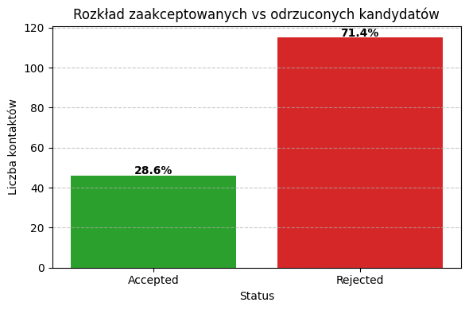

```python
accepted_total = vac["accepted"].sum()
rejected_total = vac["rejected"].sum()

acceptance_data = pd.DataFrame({
    "status": ["Accepted", "Rejected"],
    "count": [accepted_total, rejected_total]
})

summary = acceptance_data.copy()
total = summary['count'].sum()
summary['percentage'] = (summary['count'] / total * 100).round(1)

plt.figure(figsize=(6, 4))
bars = plt.bar(summary["status"], summary["count"], color=["#2ca02c", "#d62728"])

# Dodanie tekstu nad słupkami
for bar, pct in zip(bars, summary['percentage']):
    height = bar.get_height()
    plt.text(bar.get_x() + bar.get_width() / 2, height -0.5, f"{pct}%",
             ha='center', va='bottom', fontsize=10, fontweight='bold')

plt.title("Rozkład zaakceptowanych vs odrzuconych kandydatów")
plt.xlabel("Status")
plt.ylabel("Liczba kontaktów")
plt.grid(axis='y', linestyle='--', alpha=0.7)
plt.tight_layout()
plt.show()
```

```python
summary
```

|  | status | count | percentage |
| --- | --- | --- | --- |
| 0 | Accepted | 46 | 28.6 |
| 1 | Rejected | 115 | 71.4 |

Na podstawie powyższego wykresu i tabeli wnioskujemy, że spośród wszystkich kandydatów aplikujących na oferty:

- 28,6% zostało zaakceptowanych (46 przypadków)
- natomiast aż 71,4% zostało odrzuconych (115 przypadków)

Wskazuje to na silną selektywność - większość kandydatów nie spełniła wymagań rekrutacyjnych. Może to sugerować niedopasowanie umijętności, niewystarczające doświadczenie lub inne braki względem oczekiwań ofertowych. Informacja ta może być pomocna do wylapienia tendencji w ocenie dopasowania kandydatów do ofert.

### Rozkład profili ofert

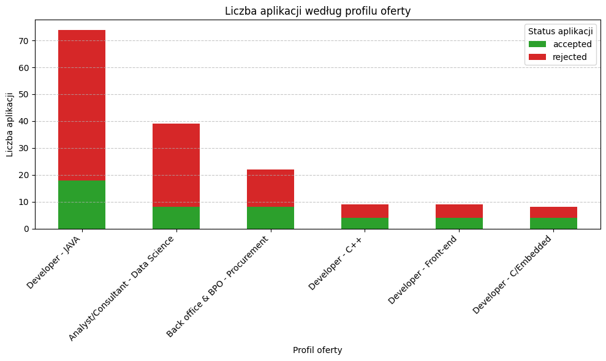

```python
applications_per_profile = vac.groupby("name_profile")[["accepted", "rejected"]].sum().sort_values(by=["accepted", "rejected"], ascending=False)

plt.figure(figsize=(10, 6))
applications_per_profile.plot(
    kind='bar',
    stacked=True,
    color=['#2ca02c', '#d62728'],
    figsize=(10, 6)
)

plt.title("Liczba aplikacji według profilu oferty")
plt.xlabel("Profil oferty")
plt.ylabel("Liczba aplikacji")
plt.xticks(rotation=45, ha='right')
plt.grid(axis='y', linestyle='--', alpha=0.7)
plt.tight_layout()
plt.legend(title="Status aplikacji")
plt.show()
```

Wykres przedstawia łączną liczbę aplikacji (zaakceptowanych i odrzuconych) dla każdego profilu oferty. Najpopularniejsza oferta według kandydatów to **Developer – JAVA** – ponad 70 aplikacji. Również stosunkowo sporo kandydatów aplikowały się na ofertę **Analyst/Consultant – Data Science** (prawie 40) oraz **Back office & BPO – Procurement** (ponad 20). Natomiast, pozostałe oferty takie jak **Developer - C++**, **Developer- Front-end** czy **Developer - C/Embedded**, otrzymały znacznie mniej aplikacji (poniżej 10 każda).

***Z tej analizy wynikają ewentualne problemy w modelowaniu:***

Ponieważ są oferty z niską liczbą aplikacji, to np. metoda dopasowania wyłącznie po wspólnych skillach może nie znaleźć żadnych pasujących kandydatów, bo jest ich po prostu za mało.

Mamy do dyspozycji bardzo mało danych treningowych, więc nie da się zastosować uczenia maszynowego czy statystycznego rankingowania.

***Jak można je rozwiązać?***

Przede wszystkim - uzupełnienie zbioru:

- dane o kontekście firmy (lokalizacja, typ umowy, ..)
- dane behawioralne o kandydacie (soft skills, dostępność, ..)
- więcej przypadków `accepted` i `rejected` -> więcej obserwacji -> większe szansy na skuteczny trening modelu
- dane do ewaluacji (informacjia, czy kandydat został zatrudniony)

### Czy status aplikacji zależy od profilu oferty?

Żeby odpowiedzieć na to pytanie przeprowadzimy test statystyczny $\chi^2$ o hipotezach:

$H_0$: Status aplikacji nie zależy od profilu oferty

$H_1$: Status aplikacji zależy od profilu oferty

```python
contingency = vac.groupby("name_profile")[["accepted", "rejected"]].sum()

chi2, p, dof, expected = stats.chi2_contingency(contingency)

print("Test chi-kwadrat")
print("----------------")
print(f"Statystyka chi²: {chi2:.3f}")
print(f"Liczba stopni swobody: {dof}")
print(f"p-value: {p:.4f}")
```

```
Test chi-kwadrat
----------------
Statystyka chi²: 6.572
Liczba stopni swobody: 5
p-value: 0.2545
```

Na podstawie przeprowadzonego testu zależności $\chi^2$, p-wartość jest większa niż ustalony poziom istotności 0.05, więc nie mamy podstaw do odrzucenia $H_0$. Status aplikacji nie zależy od profilu oferty.

### Rozkład minimalnego wymaganego doświadczenia

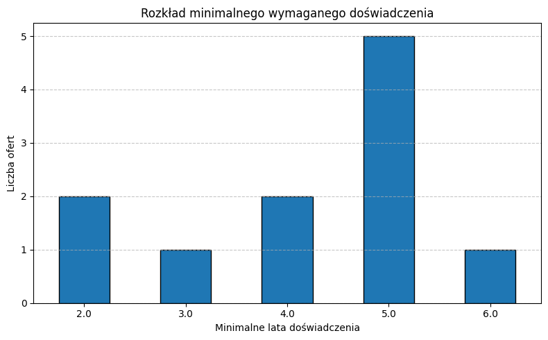

```python
experience_counts = vac["experience_years_min"].value_counts().reindex([2.0, 3.0, 4.0, 5.0, 6.0], fill_value=0)

plt.figure(figsize=(8, 5))
experience_counts.plot(kind='bar', edgecolor='black')

plt.title("Rozkład minimalnego wymaganego doświadczenia")
plt.xlabel("Minimalne lata doświadczenia")
plt.ylabel("Liczba ofert")
plt.xticks(rotation=0)
plt.grid(axis='y', linestyle='--', alpha=0.7)
plt.tight_layout()
plt.show()
```

Wykres przedstawia liczbę ofert w zależności od minimalnej liczby lat doświadczenia wymaganej przez firmę. Najwięcej ofert **(5)** wymaga co najmniej 5 lat doświadczenia, co wskazuje na duże zapotrzebowanie na kandydatów o bardziej zaawansowanym profilu zawodowym.

Można zauważyć, że:

- dominują oferty wymagające 4–5 lat doświadczenia, co może być barierą dla osób dopiero rozpoczynających karierę
- przy budowaniu modelu rekomendacyjnego warto uwzględniać ten aspekt jako jeden z kluczowych warunków filtrowania kandydatów - np. nie warto proponować kandydatów z 2-letnim doświadczeniem do ofert wymagających 6 lat.

```python
fig = px.scatter(
    vac,
    x="offer_id",
    y="experience_years_min",
    text="name_profile",
    title="Minimalne wymagane doświadczenie według ID oferty",
    labels={
        "offer_id": "ID oferty",
        "experience_years_min": "Minimalne lata doświadczenia"
    },
)

fig.update_traces(textposition='top center', marker=dict(size=10, color='cornflowerblue'))

fig.update_layout(
    height=500,
    width=900,
    plot_bgcolor='white',
    xaxis=dict(showgrid=True, gridcolor='lightgray'),
    yaxis=dict(showgrid=True, gridcolor='lightgray'),
)

fig.show()

pio.write_html(fig, file="plot_experience_vs_offer.html", auto_open=True)

#P.S.

#Jeśli jest problem z wyświetleniem wykresu - można go zobaczyć w pliku tego projektu pod nazwą 'plot_experience_vs_offer.html'.
```

[output not shown]

Tu przedstawiłem nieco inną interaktywną wizualizację minimalnego wymaganego doświadczenia według ofert.

### Rozkład doświadczenia kandydatów

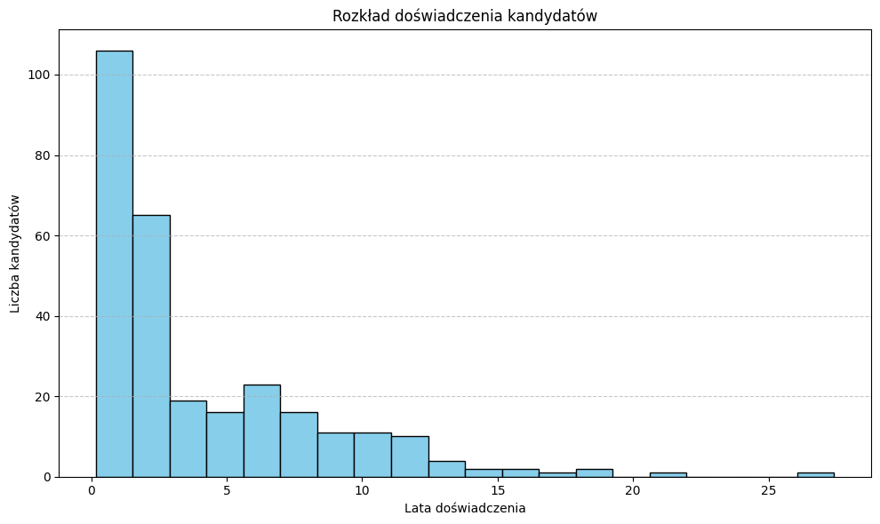

```
Współczynnik asymetrii (skewness): 1.82
```

```python
plt.figure(figsize=(10, 6))
plt.hist(contact_profiles["experience_calculated"], bins=20, edgecolor='black', color='skyblue')
plt.title("Rozkład doświadczenia kandydatów")
plt.xlabel("Lata doświadczenia")
plt.ylabel("Liczba kandydatów")
plt.grid(axis='y', linestyle='--', alpha=0.7)
plt.tight_layout()
plt.show()

skewness = skew(contact_profiles["experience_calculated"].dropna())
print(f"Współczynnik asymetrii (skewness): {skewness:.2f}")
```

```python
contact_profiles["experience_calculated"].describe().round(2).to_frame()
```

|  | experience_calculated |
| --- | --- |
| count | 290.00 |
| mean | 4.09 |
| std | 4.25 |
| min | 0.17 |
| 25% | 1.22 |
| 50% | 1.85 |
| 75% | 6.06 |
| max | 27.42 |

Powyższy wykres oraz tabela przedstawiają rozkład liczby lat doświadczenia wśród wszystkich kandydatów. Rozkład pokazuje silną prawostronną skosność, co podtwierdza współczynnik asymetrii wynoszący 1.82 (jeśli > 0, asymetria prawostronna). Oznacza to, że większość kandydatów ma relatywnie niewielkie doświadczenie zawodowe.

- 75% kandydatów ma mniej niż 6,06 lat doświadczenia, co pokazuje, że dominują osoby na poziomie junior lub early-mid
- średnia (4,09 roku) jest nieco zawyżona przez nieliczne przypadki z bardzo dużym doświadczeniem (maks. 27,42 roku)

***Wnioski dla modelu rekomendacyjnego:***

- wymagania ofert pracy (gdzie często oczekuje się 4–6 lat doświadczenia) mogą być niedopasowane do kandydatów, co może tłumaczyć wysoki odsetek odrzuconych aplikacji
- dobrym pomysłem może być tolerancja na niepełne spełnienie wymagań lub wzmacnianie punktacji za kluczowe umiejętności (większe wagi, jeśli *obligatory*) mimo mniejszego doświadczenia

P.S.

Skoro mamy wyraźną prawostronną asymetrie - moglibyśmy zlogarytmizować `experience_calculated` przez $log_{10}$ w celu zbliżenia rozkładu do normalnego, który lepiej nadaje się modelowaniu.

### Top 10 najczęściej wymaganych vs posiadanych skillów

```python
top_required = vac_skills["skill"].value_counts().head(10) #top 10 wymaganych
top_possessed = contact_skills["skill"].value_counts().head(10) #top 10 posiadanych

skills_df = pd.DataFrame({
    "Required": top_required,
    "Possessed": top_possessed
})
```

```python
skills_df[skills_df.isnull().any(axis=1)]
```

| skill | Required | Possessed |
| --- | --- | --- |
| customer | 3.0 | NaN |
| docker | NaN | 101.0 |
| git | NaN | 101.0 |
| global | 3.0 | NaN |
| google-cloud-platform | 3.0 | NaN |
| management | 5.0 | NaN |
| platform | 4.0 | NaN |
| platforms | 3.0 | NaN |
| postgresql | NaN | 74.0 |
| python | NaN | 80.0 |
| software-development | NaN | 83.0 |
| sql | NaN | 81.0 |

W ramce danych najczęściej wymaganych vs posiadanych skilli są wartości brakujące. Wynika to z tego, że spośrod top 10 najczęściej wymaganych skilli są takie, których nie ma w najczęściej posiadanych skilli i naodwrót.

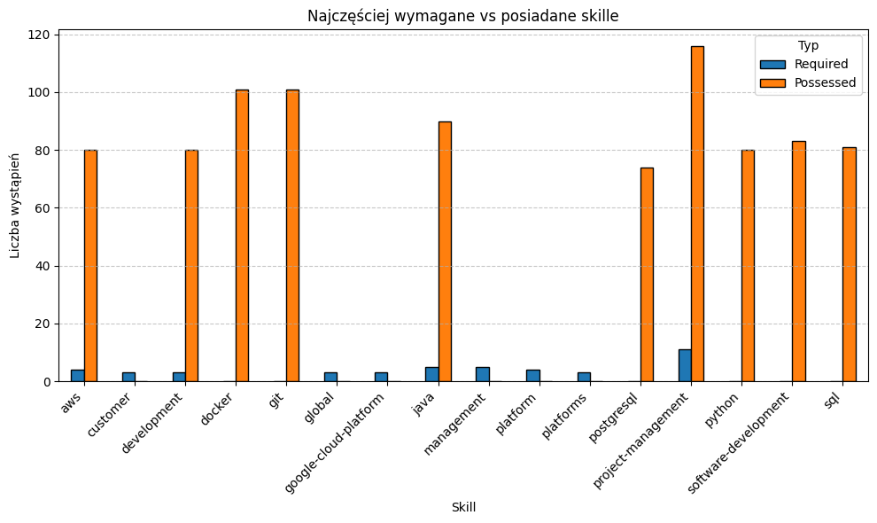

```python
skills_df = skills_df.fillna(0).astype(int)

skills_df.plot(kind='bar', figsize=(10, 6), edgecolor='black')
plt.title("Najczęściej wymagane vs posiadane skille")
plt.xlabel("Skill")
plt.ylabel("Liczba wystąpień")
plt.xticks(rotation=45, ha='right')
plt.legend(title="Typ")
plt.grid(axis='y', linestyle='--', alpha=0.7)
plt.tight_layout()
plt.show()
```

Wykres przedstawia porównanie top 10 najczęściej wymaganych vs posiadanych skillów.

Umiejętności takie jak *project-management*, *docker*, *git*, *java*, *software-development*, *development* czy *aws* są bardzo powszechnie posiadane przez kandydatów. Jednak te skille są relatywnie rzadko wymagane w ofertach, większość pojawia się tylko kilka razy (*project-management*, *java*, *development*, *aws*).

***Wnioski dla modelu rekomendacyjnego:***

- kandydaci są bardziej "uzbrojeni" w kompetencje, niż może wynikać z treści ofert – warto brać to pod uwagę przy scoringu (wagi dla *optional*, *description* i *obligatory*)
- korzystanie z metody domyślania się brakujących wymagań - reguły asocjacyjne
- wskażnik matchowania skilli wymaganych i posiadanych

### Jakie skille są najczęstsze dla konkretnych profili ofert?

```python
skills_profiles = contact_skills.merge(contact_profiles, on="contact_id")
print(skills_profiles['skill'].nunique())
skills_profiles.head()
```

```
3433
```

|  | contact_id | skill | name_profile | is_main_profile | is_preferred_profile | experience_calculated |
| --- | --- | --- | --- | --- | --- | --- |
| 0 | 1 | tensorflow | Analyst/Consultant - Data Science | False | True | 7.33 |
| 1 | 1 | tensorflow | Developer - AI/ML | True | True | 0.67 |
| 2 | 1 | matlab | Analyst/Consultant - Data Science | False | True | 7.33 |
| 3 | 1 | matlab | Developer - AI/ML | True | True | 0.67 |
| 4 | 1 | java | Analyst/Consultant - Data Science | False | True | 7.33 |

Przede wszystkim, łączymy umiejętności z profilami. Zauważamy, że są 3433 unikalnych wartości skillów posiadanych przez kandydatów.

```python
skill_counts = skills_profiles.groupby(["name_profile", "skill"]).size().unstack(fill_value=0)
skill_counts.head()
```

| skill name_profile | ) java ee(servlets) | .net | .net cf with gapi | 1-wire | 3d | 3d-animation | 3d-modelling | 3d-printing | 3d-secure | 3dsmax | ... | zarzadzanie ryzykiem | zdolnosc adaptacji | zen-coding | zend-framework | zendesk | zephyr | zookeeper | zoom | zos | zuora |
| --- | --- | --- | --- | --- | --- | --- | --- | --- | --- | --- | --- | --- | --- | --- | --- | --- | --- | --- | --- | --- | --- |
| Administrator - DevOps | 0 | 0 | 0 | 0 | 0 | 0 | 0 | 0 | 0 | 0 | ... | 0 | 0 | 0 | 0 | 0 | 0 | 0 | 0 | 0 | 0 |
| Analyst/Consultant - AML/KYC | 0 | 0 | 0 | 0 | 0 | 0 | 0 | 0 | 0 | 0 | ... | 0 | 0 | 0 | 0 | 0 | 0 | 0 | 0 | 0 | 0 |
| Analyst/Consultant - Business | 0 | 0 | 0 | 0 | 0 | 0 | 0 | 0 | 0 | 0 | ... | 0 | 0 | 0 | 0 | 0 | 0 | 0 | 0 | 0 | 0 |
| Analyst/Consultant - Data Science | 0 | 1 | 0 | 0 | 1 | 0 | 0 | 0 | 0 | 0 | ... | 0 | 0 | 0 | 1 | 0 | 0 | 0 | 0 | 0 | 0 |
| Analyst/Consultant - Data/Big Data | 0 | 2 | 0 | 0 | 0 | 0 | 0 | 0 | 0 | 0 | ... | 1 | 0 | 0 | 1 | 0 | 0 | 0 | 0 | 0 | 0 |

5 rows × 3433 columns

Grupujemy, ile razy dany skill występuje w danym profilu.

```python
top_skills = skill_counts.sum().sort_values(ascending=False).head(10).index
heatmap_data = skill_counts[top_skills]
heatmap_data.head()
```

| skill name_profile | project-management | git | docker | python | sql | software-development | java | development | aws | linux |
| --- | --- | --- | --- | --- | --- | --- | --- | --- | --- | --- |
| Administrator - DevOps | 2 | 2 | 2 | 2 | 1 | 1 | 2 | 2 | 2 | 0 |
| Analyst/Consultant - AML/KYC | 1 | 1 | 1 | 1 | 1 | 0 | 1 | 1 | 0 | 0 |
| Analyst/Consultant - Business | 0 | 0 | 1 | 1 | 1 | 1 | 0 | 1 | 0 | 1 |
| Analyst/Consultant - Data Science | 20 | 15 | 14 | 24 | 20 | 10 | 8 | 9 | 14 | 11 |
| Analyst/Consultant - Data/Big Data | 12 | 4 | 5 | 9 | 8 | 5 | 2 | 5 | 5 | 7 |

Ograniczamy do top 10 najczęstszych skillów.

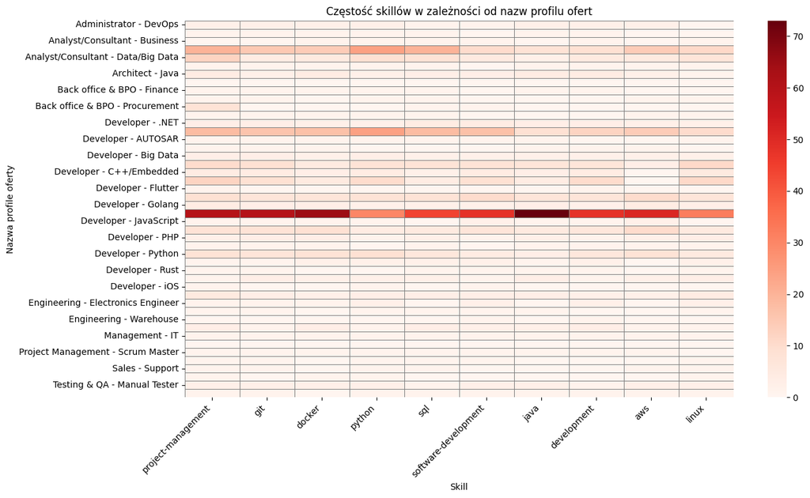

```python
plt.figure(figsize=(14, 8))
sns.heatmap(heatmap_data, cmap="Reds", linewidths=0.5, linecolor='gray')
plt.title("Częstość skillów w zależności od nazw profilu ofert")
plt.xlabel("Skill")
plt.ylabel("Nazwa profile oferty")
plt.xticks(rotation=45, ha='right')
plt.tight_layout()
plt.show()
```

### Liczba kandydatów względem kombinacji profili (główny-preferowany)

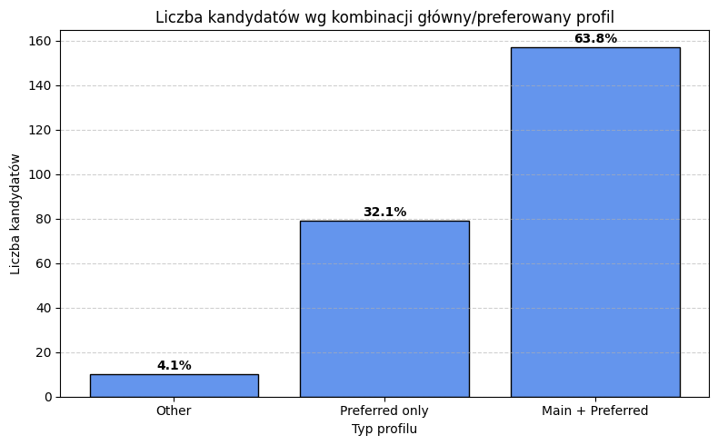

```python
profile_combo_counts = contact_profiles.groupby(["is_main_profile", "is_preferred_profile"])["contact_id"].nunique().reset_index()

def label_flags(row):
    if row["is_main_profile"] and row["is_preferred_profile"]:
        return "Main + Preferred"
    elif row["is_main_profile"]:
        return "Main only"
    elif row["is_preferred_profile"]:
        return "Preferred only"
    else:
        return "Other"

profile_combo_counts["Kategoria"] = profile_combo_counts.apply(label_flags, axis=1)

profile_data = profile_combo_counts[["Kategoria", "contact_id"]].rename(columns={"contact_id": "Liczba kandydatów"})

total_candidates = profile_data["Liczba kandydatów"].sum()
profile_data["Procent"] = (profile_data["Liczba kandydatów"] / total_candidates * 100).round(1)

plt.figure(figsize=(8, 5))
bars = plt.bar(profile_data["Kategoria"], profile_data["Liczba kandydatów"], color = "cornflowerblue", edgecolor="black")

for bar, percent in zip(bars, profile_data["Procent"]):
    plt.text(
        bar.get_x() + bar.get_width() / 2,
        bar.get_height() + 1,
        f"{percent}%",
        ha="center", va="bottom", fontsize=10, fontweight='bold'
    )

plt.title("Liczba kandydatów wg kombinacji główny/preferowany profil")
plt.xlabel("Typ profilu")
plt.ylabel("Liczba kandydatów")
plt.grid(axis='y', linestyle='--', alpha=0.6)
plt.tight_layout()
plt.show()
```

```python
len(contact_profiles[(contact_profiles["is_main_profile"] == True) & (contact_profiles["is_preferred_profile"] == False)])
```

```
0
```

Wykres przedstawia rozkład kandydatów względem wybranych profili.

Zdecydowana większość kandydatów (**64%**) zadeklarowała swój profil zarówno jako główny, jak i preferowany (`Main + Preffered`). Oznacza to, że większość jest zdecydowana na kontynuację rozwoju w swoim profilu.

Relatywnie spora część kandydatów (**32%**) posiada tylko profil preferowany (`Preferred only`). To może oznaczać, że kandydaci sa otwarci na rozwój w nowym profilu.

Niewielki odsetek kandydatów (**4%**) nie posiada ani profilu głównego, ani preferowanego (`Other`). Co może wskazywać na częściowo uzupełniane profili.

***Co też istotne***:

Brak kandydatów posiadających wyłącznie profil główny (`Main only`). Oznacza to, że jeśli profil jest oznaczony jako główny, to zawsze jest też preferowany.

***Wniosek do modelu rekomendacyjnego:***

Należy bazować głównie na preferowanym profilu, a główny profil traktować jedynie jako dodatkowy sygnał pomocniczy (np. historyczny).

### Histogram wartości `confidence` i `lift`

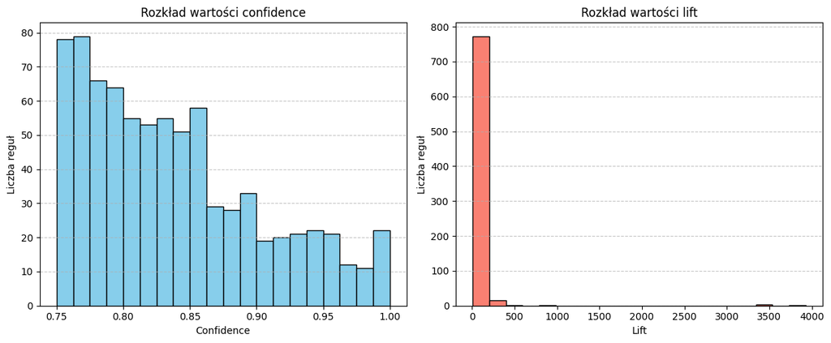

```python
plt.figure(figsize=(12, 5))

plt.subplot(1, 2, 1)
plt.hist(asoc_rules["confidence"], bins=20, color="skyblue", edgecolor="black")
plt.title("Rozkład wartości confidence")
plt.xlabel("Confidence")
plt.ylabel("Liczba reguł")
plt.grid(axis='y', linestyle='--', alpha=0.7)

plt.subplot(1, 2, 2)
plt.hist(asoc_rules["lift"], bins=20, color="salmon", edgecolor="black")
plt.title("Rozkład wartości lift")
plt.xlabel("Lift")
plt.ylabel("Liczba reguł")
plt.grid(axis='y', linestyle='--', alpha=0.7)

plt.tight_layout()
plt.show()
```

Wykresy przedstawiają metryki jakości reguł asocjacyjnych między skillami kandydatów:

**Confidence – wiarygodność reguły**:

- większość reguł ma wartość `confidence` pomiędzy 0.75 a 0.90
- niewielka liczba reguł osiąga wartość bliską 1.0, co oznacza bardzo silne powiązanie

Oznacza to, że reguły są umiarkowanie pewne, ale niekoniecznie deterministyczne – można ich używać do uzupełniania profilu, ale z zachowaniem ostrożności.

**Lift – siła reguły względem niezależności**

- rozkład `lift` jest silnie prawoskośny, z większością wartości poniżej `500`
- istnieją nieliczne reguły o ekstremalnie wysokim `lift` (nawet > 3000), co może wskazywać na bardzo rzadkie, ale znaczące powiązania

Przy budowie modelu rekomendacyjnego można ustawić próg liftu minimalnego (np. lift > 1.0) by pominąć reguły bez wartości dodanej, a jednocześnie filtrować reguły z ekstremalnym lift (np. lift > 500) jako potencjalnie niestabilne.

***Wniosek do modelu rekomendacyjnego:***

Reguły asocjacyjne można wykorzystać do inteligentnego uzupełniania brakujących skillów kandydatów, np. gdy model widzi *mcal*, może zasugerować *autosar*. Jednak należy stosować progi `confidence` i `lift`, by zachować jakość wnioskowania. Również, najlepiej działać na profilach z większą liczbą obserwacji.

### Top 10 najbardziej wiarygodnych reguł asocjacyjnych

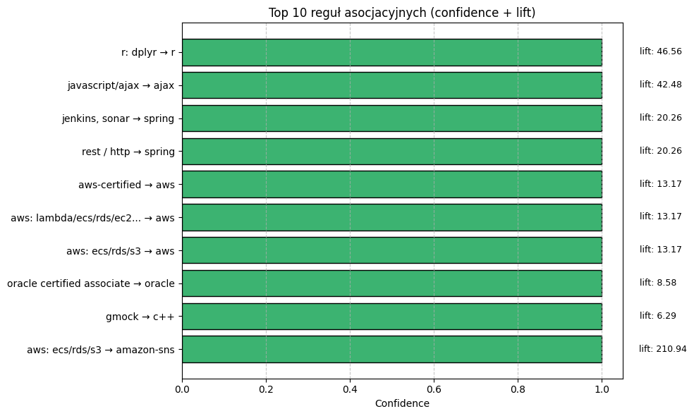

```python
asoc_rules["rule"] = asoc_rules["lhs"] + " → " + asoc_rules["rhs"]

top_combined = asoc_rules.sort_values(by=["confidence", "lift"], ascending=[False, False]).head(10)

plt.figure(figsize=(10, 6))
bars = plt.barh(top_combined["rule"], top_combined["confidence"], color="mediumseagreen", edgecolor="black")
plt.xlabel("Confidence")
plt.title("Top 10 reguł asocjacyjnych (confidence + lift)")
plt.gca().invert_yaxis()
plt.grid(axis='x', linestyle='--', alpha=0.7)

for bar, lift_value in zip(bars, top_combined["lift"]):
    plt.text(
        bar.get_x() + bar.get_width() + 0.09,
        bar.get_y() + bar.get_height() / 2,
        f"lift: {round(lift_value, 2)}",
        va="center", fontsize=9
    )

plt.tight_layout()
plt.show()
```

```python
top_combined
```

|  | lhs | rhs | confidence | lift | rule |
| --- | --- | --- | --- | --- | --- |
| 625 | r: dplyr | r | 1.0000 | 46.5585 | r: dplyr → r |
| 0 | javascript/ajax | ajax | 1.0000 | 42.4798 | javascript/ajax → ajax |
| 63 | jenkins, sonar | spring | 1.0000 | 20.2555 | jenkins, sonar → spring |
| 176 | rest / http | spring | 1.0000 | 20.2555 | rest / http → spring |
| 19 | aws-certified | aws | 1.0000 | 13.1687 | aws-certified → aws |
| 717 | aws: lambda/ecs/rds/ec2... | aws | 1.0000 | 13.1687 | aws: lambda/ecs/rds/ec2... → aws |
| 721 | aws: ecs/rds/s3 | aws | 1.0000 | 13.1687 | aws: ecs/rds/s3 → aws |
| 794 | oracle certified associate | oracle | 1.0000 | 8.5774 | oracle certified associate → oracle |
| 795 | gmock | c++ | 1.0000 | 6.2877 | gmock → c++ |
| 718 | aws: ecs/rds/s3 | amazon-sns | 0.9995 | 210.9438 | aws: ecs/rds/s3 → amazon-sns |

Powyższy wykres oraz tablea prezentują 10 najmocniejszych reguł asocjacyjnych między skillami, posortowanych według dwóch metryk jakości:

- `Confidence` (oś X) – wiarygodność reguły, czyli jak często `rhs` występuje, gdy pojawi się `lhs`.
- `Lift` (etykiety) – siła powiązania względem niezależności (czy `rhs` naprawdę wynika z `lhs`).

**Co widzimy**:

- Wszystkie reguły w zaokrągleniu mają `confidence` = 1.0, co oznacza, że prawy składnik występuje zawsze, gdy występuje lewy.
- Natomiast kluczowe różnice wynikają z wartości `lift`:
  - Przykład: *aws: ecs/rds/s3* → *amazon-sns* ma ekstremalnie wysoki `lift`: 211, co oznacza, że współwystępowanie tych dwóch umiejętności jest ponad 200 razy bardziej prawdopodobne niż losowe. Jednak współczynnik `confidence` wynosi 0.9995 $\approx$ 1.0, dla tego wiersz ten jest na najniższej pozycji.
  - Reguły takie jak *r: dplyr* → *r* czy *javascript/ajax* → *ajax* również mają bardzo wysoki `lift`, co wskazuje na silne i często spotykane zależności.
- Z drugiej strony np. *gmock* → *c++* mimo `confidence` = 1.0 ma niższy `lift`, co oznacza, że c++ występuje tak często ogólnie, że reguła wnosi mniej wartości dodanej.

***Wniosek do modelu rekomendacyjnego:***

Te reguły są bardzo wiarygodne i mogą być:

- użyte do wzbogacania profilu kandydata (np. automatyczne dodanie `c++` przy `gmock`)
- traktowane jako twarde reguły w dopasowaniu (np. jeśli ktoś ma `lhs`, a nie ma `rhs`, jego profil może być uznany za niekompletny).

# 2. Model / Heurystyka

## 2.1. System rekomendacyjny content-based

Metoda **content-based** polega na rekomendowaniu kandydatów, którzy najlepiej pasują do ofert na podstawie ich profilu oraz wymaganych umiejętności. Biorąc pod uwagę specyfikę zbiorów, zawierających profile kandydatów, wymagane umiejętności oraz doświadczenie, – ten typ rekomendacji wydaje się najbardziej logiczny do szybkiego wdrożenia.

### 2.1.1. Tworzenie macierzy cech

```python
all_skills = sorted(set(vac_skills["skill"]).union(set(contact_skills["skill"])))
print(f"Liczba unikalnych umiejętności: {len(all_skills)}")
```

```
Liczba unikalnych umiejętności: 3469
```

Wspólna przestrzeń unikalnych umijętności ze zbioru `vac_skills` i `contact_skills`.

```python
weights = {'optional': 0.3, 'description': 0.5, 'obligatory': 1.0}
vac_skills["weight"] = vac_skills["source_type"].map(weights)
```

Ustawiamy wagi dla różnych wartości `source_type`:

- optional → 0.3
- description → 0.5
- obligatory → 1.0

Czyli najistotniejsze skille (*obligatory*) są mnożone przez 1, *description* (mniej istotne) przez 0.5, *optional* (opcjonalne) - przez 0.3.

```python
vac_skills.dtypes
```

```
offer_id          int32
skill            object
source_type    category
weight         category
dtype: object
```

W zbiorze danych **vac_skills** kolumna `weight` jest typu *category* - nie obsługuje operatora sumy, z którego skorzystamy w następnym kroku. Więc konwertujemy ją na typ *str*.

```python
vac_skills["weight"] = vac_skills["weight"].astype(str)

offer_skill_matrix_weighted = vac_skills.pivot_table(
    index="offer_id",
    columns="skill",
    values="weight",
    aggfunc="sum",
    fill_value=0
).reindex(columns=all_skills, fill_value=0)

offer_skill_matrix_weighted.head()
```

| skill offer_id | ) java ee(servlets) | .net | .net cf with gapi | 1-wire | 3d | 3d-animation | 3d-modelling | 3d-printing | 3d-secure | 3dsmax | ... | zarzadzanie ryzykiem | zdolnosc adaptacji | zen-coding | zend-framework | zendesk | zephyr | zookeeper | zoom | zos | zuora |
| --- | --- | --- | --- | --- | --- | --- | --- | --- | --- | --- | --- | --- | --- | --- | --- | --- | --- | --- | --- | --- | --- |
| 1 | 0 | 0 | 0 | 0 | 0 | 0 | 0 | 0 | 0 | 0 | ... | 0 | 0 | 0 | 0 | 0 | 0 | 0 | 0 | 0 | 0 |
| 2 | 0 | 0 | 0 | 0 | 0 | 0 | 0 | 0 | 0 | 0 | ... | 0 | 0 | 0 | 0 | 0 | 0 | 0 | 0 | 0 | 0 |
| 3 | 0 | 0 | 0 | 0 | 0 | 0 | 0 | 0 | 0 | 0 | ... | 0 | 0 | 0 | 0 | 0 | 0 | 0 | 0 | 0 | 0 |
| 4 | 0 | 0 | 0 | 0 | 0 | 0 | 0 | 0 | 0 | 0 | ... | 0 | 0 | 0 | 0 | 0 | 0 | 0 | 0 | 0 | 0 |
| 5 | 0 | 0 | 0 | 0 | 0 | 0 | 0 | 0 | 0 | 0 | ... | 0 | 0 | 0 | 0 | 0 | 0 | 0 | 0 | 0 | 0 |

5 rows × 3469 columns

Zrobiliśmy one-hot encoding macierzy wraz z odpowiednimi wagami dla skilli z ofert.

```python
offer_features_weighted = offer_skill_matrix_weighted.merge(
    vac[["offer_id", "experience_years_min"]],
    left_index=True,
    right_on="offer_id"
).set_index("offer_id")

scaler = MinMaxScaler()
offer_features_weighted["experience_years_min_norm"] = scaler.fit_transform(
    offer_features_weighted[["experience_years_min"]]
)

offer_features_weighted.drop(columns=["experience_years_min"], inplace=True)
offer_features_weighted["experience_years_min_norm"].head()
```

```
offer_id
1    0.75
2    0.00
3    0.25
4    0.50
5    0.75
Name: experience_years_min_norm, dtype: float64
```

Dodaliśmy do macierzy jeszcze minimalne wymagane doświadczenie oraz znormalizowaliśmy go do przedziału (0,1). Przeprowadziliśmy normalizację w celu sprowadzenia zmiennej do jednej skali z inynmi, korzystając ze wzoru:

$$ x' = \frac{x - x_{\text{min}}}{x_{\text{max}} - x_{\text{min}}} $$

Gdzie:

- $x$ – wartość oryginalna
- $x_{\text{min}}$, $x_{\text{max}}$ – minimalna i maksymalna wartość w danej kolumnie.

```python
contact_skill_matrix = contact_skills.pivot_table(
    index="contact_id",
    columns="skill",
    aggfunc="size",
    fill_value=0
).reindex(columns=all_skills, fill_value=0)

contact_skill_matrix.head()
```

| skill contact_id | ) java ee(servlets) | .net | .net cf with gapi | 1-wire | 3d | 3d-animation | 3d-modelling | 3d-printing | 3d-secure | 3dsmax | ... | zarzadzanie ryzykiem | zdolnosc adaptacji | zen-coding | zend-framework | zendesk | zephyr | zookeeper | zoom | zos | zuora |
| --- | --- | --- | --- | --- | --- | --- | --- | --- | --- | --- | --- | --- | --- | --- | --- | --- | --- | --- | --- | --- | --- |
| 1 | 0 | 0 | 0 | 0 | 0 | 0 | 0 | 0 | 0 | 0 | ... | 0 | 0 | 0 | 0 | 0 | 0 | 0 | 0 | 0 | 0 |
| 2 | 0 | 0 | 0 | 0 | 0 | 0 | 0 | 0 | 0 | 0 | ... | 0 | 0 | 0 | 0 | 0 | 0 | 0 | 0 | 0 | 0 |
| 3 | 0 | 0 | 0 | 0 | 0 | 0 | 0 | 0 | 0 | 0 | ... | 0 | 0 | 0 | 0 | 0 | 0 | 0 | 0 | 0 | 0 |
| 4 | 0 | 0 | 0 | 0 | 0 | 0 | 0 | 0 | 0 | 0 | ... | 0 | 0 | 0 | 0 | 0 | 0 | 0 | 0 | 0 | 0 |
| 5 | 0 | 0 | 0 | 0 | 0 | 0 | 1 | 0 | 0 | 0 | ... | 0 | 0 | 0 | 0 | 0 | 0 | 0 | 0 | 0 | 0 |

5 rows × 3469 columns

Zrobiliśmy one-hot encoding macierzy dla skilli z profili kandydatów.

```python
contact_features = contact_skill_matrix.merge(
    contact_profiles[["contact_id", "experience_calculated"]],
    left_index=True,
    right_on="contact_id"
).set_index("contact_id")

contact_features["experience_calculated_norm"] = scaler.fit_transform(
    contact_features[["experience_calculated"]]
)
contact_features.drop(columns=["experience_calculated"], inplace=True)

contact_features["experience_calculated_norm"].head()
```

```
contact_id
1    0.262752
1    0.018349
2    0.229358
3    0.232294
3    0.044404
Name: experience_calculated_norm, dtype: float64
```

**Reasumując**, stworzyliśmy dwie macierzy: `offer_features_weighted` i `contact_features`.

Dla pierwszej macierzy (oferty):

- Zamiast binarnych wartości dla umiejętności, mamy teraz wartości ważone odzwierciedlające ich istotność.
- Umiejętność oznaczona jako *obligatory* jest bardziej wartościowa niż *optional* czy *description*.

Dla drugiej macierzy (kandydaci):

- Nadal binarnie reprezentowani (posiada/nie posiada umiejętności).
- Doświadczenie wciąż normalizowane.

### 2.1.2. Obliczenie podobieństwa (Cosine Similarity)

```python
common_features = offer_features_weighted.columns.intersection(contact_features.columns)
offer_matrix = offer_features_weighted[common_features].values
contact_matrix = contact_features[common_features].values
```

Upewniamy się, że kolumny w obu macierzach są identyczne i uporządkowane tak samo.

P.S.

Aby poprawnie obliczyć cosine similarity między ofertami a kandydatami, musimy porównywać ich cechy w dokładnie tej samej kolejności i zestawie.

```python
offer_ids = offer_features_weighted.index
contact_ids = contact_features.index
```

Zachowujemy indeksy, żeby wiedzieć, którego `offer_id` dotyczy który wiersz w macierzy podobieństwa.

```python
similarity_matrix = cosine_similarity(offer_matrix, contact_matrix)
similarity_matrix
```

```
array([[0.08025724, 0.08025724, 0.17012533, ..., 0.07151985, 0.07151985,
        0.07151985],
       [0.04811252, 0.04811252, 0.06799104, ..., 0.04287465, 0.04287465,
        0.04287465],
       [0.09527699, 0.09527699, 0.08617108, ..., 0.06792356, 0.06792356,
        0.06792356],
       ...,
       [0.08614776, 0.08614776, 0.18631694, ..., 0.06675573, 0.06675573,
        0.06675573],
       [0.18518519, 0.18518519, 0.11514695, ..., 0.13201967, 0.13201967,
        0.13201967],
       [0.1014301 , 0.1014301 , 0.1490712 , ..., 0.07231015, 0.07231015,
        0.07231015]])
```

Obliczyliśmy **macierz podobieństwa** (`similarity_matrix`) postaci:

- wiersz (`i`) odpowiada jednej ofercie pracy `offer_id[i]`
- kolumna (`j`) odpowiada jednemu kandydatowi `contact_id[j]`
- wartość `similarity_matrix[i][j]` = jak bardzo kandydat `j` pasuje do oferty `i` na podstawie ich cech.

Również warto wyjaśnić co to jest **cosine similarity** -

Jest to miara podobieństwa między dwoma wektorami cech. Jeśli mamy:

- wektor cech oferty: $\vec{A}$
- wektor cech kandydata: $\vec{B}$

to:

$$ \text{similarity} = \cos(\theta) = \frac{\vec{A} \cdot \vec{B}}{\|\vec{A}\| \cdot \|\vec{B}\|} $$

czyli:

- iloczyn skalarny (A · B) – sumuje "zgodne cechy" (np. wspólne skille),
- długość wektorów – normalizuje wartości.

# 3. Rezultaty

## 3.1. Generowanie rekomendacji

```python
offer_idx = list(offer_ids).index(4)
```

Wybraliśmy przykladowy id oferty numer 4 - *Analyst/Consultant - Data Science*.

```python
sims = similarity_matrix[offer_idx]

ranked = pd.DataFrame({
    "offer_id": 4,
    "contact_id": contact_ids,
    "similarity": sims
}).sort_values(by="similarity", ascending=False)

ranked["status"] = ranked["similarity"].apply(lambda x: "recommended" if x >= 0.7 else "not_recommended")

top5 = ranked.head(5)
top5
```

|  | offer_id | contact_id | similarity | status |
| --- | --- | --- | --- | --- |
| 189 | 4 | 97 | 0.255556 | not_recommended |
| 190 | 4 | 97 | 0.255556 | not_recommended |
| 258 | 4 | 141 | 0.250217 | not_recommended |
| 55 | 4 | 31 | 0.238975 | not_recommended |
| 56 | 4 | 31 | 0.238975 | not_recommended |

Dla przykładowego `offer_id` = 4 wygenerowaliśmy ranking `contact_id` (top 5 z najwyższym podobieństwem). Jeśli podobieństwo kandydata >= 0.7, to jest on rekomendowany na ofertę, w przeciwnym razie - nie.

```python
def explain_match_detailed(offer_id, contact_id):
    offer_sk = vac_skills[vac_skills["offer_id"] == offer_id]
    contact_sk = contact_skills[contact_skills["contact_id"] == contact_id]

    candidate_skills = set(contact_sk["skill"])

    obligatory = set(offer_sk[offer_sk["source_type"] == "obligatory"]["skill"])
    description = set(offer_sk[offer_sk["source_type"] == "description"]["skill"])
    optional = set(offer_sk[offer_sk["source_type"] == "optional"]["skill"])

    explanation = {
        "contact_id": contact_id,
        "obligatory_required": list(obligatory),
        "obligatory_matched": list(obligatory & candidate_skills),
        "obligatory_missing": list(obligatory - candidate_skills),

        "description_required": list(description),
        "description_matched": list(description & candidate_skills),
        "description_missing": list(description - candidate_skills),

        "optional_required": list(optional),
        "optional_matched": list(optional & candidate_skills),
        "optional_missing": list(optional - candidate_skills),

        "experience_required": vac.loc[vac["offer_id"] == offer_id, "experience_years_min"].values[0],
        "experience_actual": contact_profiles.loc[contact_profiles["contact_id"] == contact_id, "experience_calculated"].values[0],
        "profile": contact_profiles.loc[contact_profiles["contact_id"] == contact_id, "name_profile"].values[0]
    }

    return explanation
```

Funkcja, która przyjmuje jako argumenty id oferty oraz kandydata i zwraca szczególową informację, na podstawie której można zobaczyć dla czego ten kandydat został wybrany lub nie na konkretną ofertę.

## 3.2. Uzasadnienie wyboru

```python
detailed_explanations = []

for i, row in top5.iterrows():
    contact_id = row["contact_id"]
    details = explain_match_detailed(example_offer_id, contact_id)
    details["similarity"] = row["similarity"]
    detailed_explanations.append(details)

detailed_df = pd.DataFrame(detailed_explanations)
detailed_df
```

|  | contact_id | obligatory_required | obligatory_matched | obligatory_missing | description_required | description_matched | description_missing | optional_required | optional_matched | optional_missing | experience_required | experience_actual | profile | similarity |
| --- | --- | --- | --- | --- | --- | --- | --- | --- | --- | --- | --- | --- | --- | --- |
| 0 | 97 | [prompts, python, rag, llm] | [python, llm] | [prompts, rag] | [customer, fitness, production, documentation,... | [production, documentation, sales, experiments... | [customer, fitness, data-modeling, cloud-compu... | [] | [] | [] | 4.0 | 7.50 | Developer - AI/ML | 0.255556 |
| 1 | 97 | [prompts, python, rag, llm] | [python, llm] | [prompts, rag] | [customer, fitness, production, documentation,... | [production, documentation, sales, experiments... | [customer, fitness, data-modeling, cloud-compu... | [] | [] | [] | 4.0 | 7.50 | Developer - AI/ML | 0.255556 |
| 2 | 141 | [prompts, python, rag, llm] | [python, rag, llm] | [prompts] | [customer, fitness, production, documentation,... | [time, production, project-management, ai, sof... | [customer, fitness, documentation, data-modeli... | [] | [] | [] | 4.0 | 2.00 | Developer - AI/ML | 0.250217 |
| 3 | 31 | [prompts, python, rag, llm] | [python] | [prompts, rag, llm] | [customer, fitness, production, documentation,... | [documentation, data-modeling, cloud-computing... | [customer, fitness, production, analytics, pro... | [] | [] | [] | 4.0 | 1.37 | Developer - AI/ML | 0.238975 |
| 4 | 31 | [prompts, python, rag, llm] | [python] | [prompts, rag, llm] | [customer, fitness, production, documentation,... | [documentation, data-modeling, cloud-computing... | [customer, fitness, production, analytics, pro... | [] | [] | [] | 4.0 | 1.37 | Developer - AI/ML | 0.238975 |

**Rozważmy kandydata numer 97** (występuje dwukrotnie – może mieć dwa różne rekordy profilu):

- `Similarity`: 0.26
- `Obligatory matched`: ["python", "llm"] z ["prompts", "python", "rag", "llm"] → 2/4 (50%)
- `Missing obligatory`: ["prompts", "rag"]
- `Doświadczenie`: 7.5 roku vs wymagane 4.0 → spełnione
- `Profil`: Developer - AI/ML ≠ Analyst/Consultant - Data Science → brak zgodności

***Wniosek***: Kandydat ma bardzo dobre doświadczenie oraz częściowo pokrywa najważniejsze umiejętności (python, llm), co daje najwyższe `similarity`. Brak zgodności profilu i dwóch wymaganych skillów ogranicza wynik.

--

**Kandydat 31** (również powtórzony):

- `Similarity`: 0.24
- `Obligatory matched`: ["python"] → 1/4 (25%)
- `Missing obligatory`: ["prompts", "rag", "llm"]
- `Doświadczenie`: 1.37 vs wymagane 4.0 → niespełnione
- `Profil`: Developer - AI/ML ≠ Analyst/Consultant - Data Science → brak zgodności

***Wniosek***: Kandydat ma tylko jeden wymagany skill (python), mało doświadczenia oraz nieodpowiedni profil. Similarity jest najniższe, co jest zgodne z oceną heurystyczną.

## 3.3. Metryki oceny modelu

Dla modeli rekomendacyjnych powszechnie stosowane są metryki:

- Precision@K i Recall@K
- Mean Average Precision (MAP@K)
- ROC AUC / Ranking loss
- Coverage / Diversity / Novelty

Ale w tym przypadku nie możemy z nich skorzystać, ponieważ nie mamy do dyspozycji danych o faktycznych dopasowaniach kandydatów do ofert. Czyli mamy dane o liczbie zaakceptowanych i odrzuconych kandydatów (`accepted`, `rejected`) — ale bez info kto został zaakceptowany lub odrzucony.

Możemy natomiast:

- użyć heurystycznej metody oceny - (score z dopasowania)
- eksplorować pokrycie skillowe.

# 4. Wnioski

Opiszę tu wkrótce pomysły i podejścia, metryki i ich ograniczenia, testowane warianty, ślepe drogi i ogólny feedback na ten projekt :)

--

Najwięcej czasu spędziełem na zaznajomienie ze zbiorem poprzez zrozumienie zmiennych, różnych zależności, przeprowadzenia analizy wraz z testami i wizualizacjami stosując heurystyczne podejście (moim zdaniem, jest to bardzo istotne, żeby dobrze zrozumieć zbiór przed modelowaniem).

--

W modelowaniu jednym z podejść było podejścia content-based:

- profili kandydatów do stworzenia podobieństw na podstawie cech numerycznych
- analiza podobieństwa w oparciu o metrykę kosinusową.

--

A propos metryk, to standardowe metryki dla systemów rekomendacyjnych (wymieniłem w punkcie 3.3) wymagają jednoznacznie określonych pozytywnych i negatywnych przykładów oraz wystarczająco dużych zbiorów historycznych, gdzie rekomendacje były już testowane. Dla tego w naszym przypadku są trudne do zastosowania, ponieważ:

- brak jednoznacznych danych historycznych interakcji (brak wyraźnych pozytywnych lub negatywnych ocen kandydatów)
- zestaw danych ograniczony, brak dużej ilości przykładów, które umożliwiłyby wiarygodne obliczenie tych metryk.

Zatem, testowalem taki warianty:

- porównanie kandydatów za pomocą prostych kryteriów heurystycznych (np. liczba spełnionych warunków obowiązkowych, dodatkowych oraz dopasowanie opisu)
- zastosowanie modelu opartego o podobieństwo kosinusowe, aby wyłonić najlepsze dopasowanie ofert i profili.

--

Dla czego nie da się to zadanie rozwiązać na 100% ?

- brak szczegółowych danych historycznych – np. realnych decyzji rekrutacyjnych, które pozwoliłyby ocenić jakość rekomendacji w praktyce
- brak danych o preferencjach kandydatów i pracodawców – dane te mogłyby dodatkowo poprawić jakość rekomendacji
- zbyt ogólne lub niepełne opisy ofert oraz profili kandydatów – ograniczają możliwość szczegółowego porównania i dopasowania kandydatów.

--

Reasumując, jestem bardzo wdięczny za możliwość realizacji takiego projektu, w trakcie którego nauczyłem się sporo nowych i ciekawych dla mnie rzeczy. Będę również bardzo wdięczny za feedback na ten projekt :)